# Reproducing the figures of the manuscript

## Introduction

This markdown document reproduces the figures of the manuscript: [Multi-omic identification of perineurial hyperplasia and lipid-associated nerve macrophages in human polyneuropathies](https://doi.org/10.1038/s41467-025-62964-8) by Heming et al, *Nature Communications*, August 2025.

All relevant data are automatically downloaded from Zenodo.

Instructions on how to restore the environment using `renv` or `Docker` can be found in the corresponding [GitHub repository](https://github.com/mihem/pns_atlas). The corresponding website, which contains interactive visualizations of the single nucleus transcriptomics and spatial transcriptomics data, is available at [pns-atlas.mzhlab.com](https://pns-atlas.mzhlab.com/). If you have any questions, please contact us at [mheming.com](https://mheming.com/).

## Load libraries

```r
library(qs)
library(Seurat)
library(tidyverse)
library(miloDE)
library(sessioninfo)
library(EnhancedVolcano)
library(pals)
library(scMisc)
library(liana)
```

## Figure 1

**UMAP of all cells (Figure 1B)**

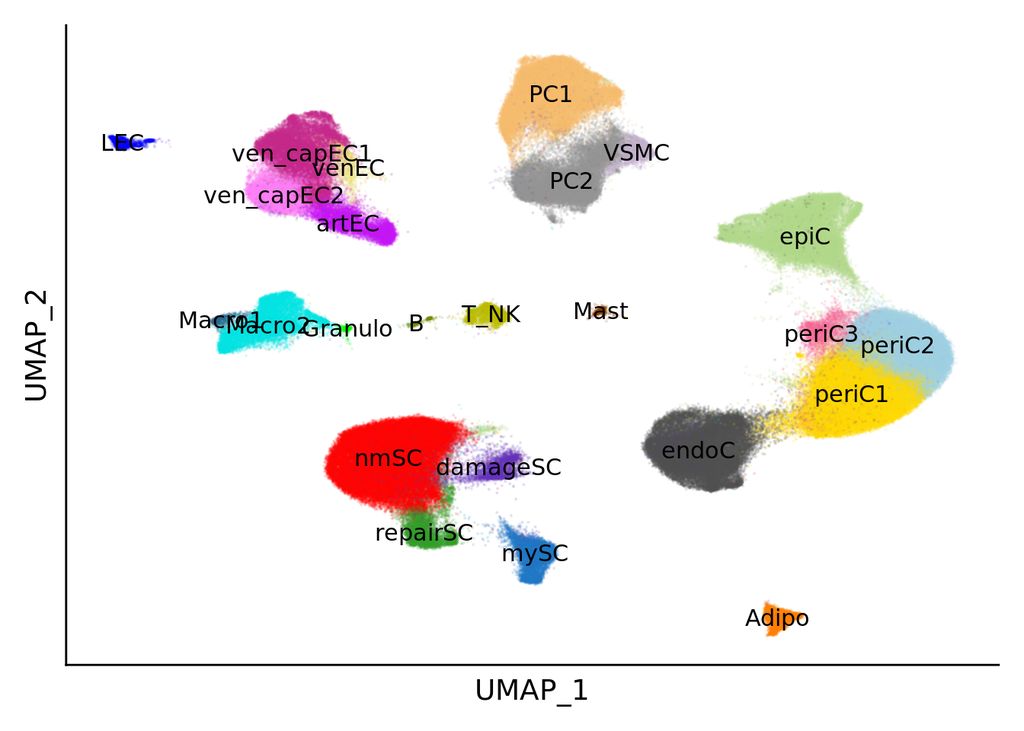

```r
options(timeout = 3600)
if (!file.exists("umap_figure.qs")) {
    download.file(
        "https://zenodo.org/records/15108216/files/umap_figure.qs?download=1",
        "umap_figure.qs"
    )
}
umap_figure <- qread("umap_figure.qs")
DimPlot(
    umap_figure,
    reduction = "umap.scvi.full",
    pt.size = .1,
    alpha = .1,
    cols = umap_figure@misc$cluster_col,
    label = TRUE,
    raster = FALSE
) +
    NoLegend() +
    theme(
        axis.text = element_blank(),
        axis.ticks = element_blank()
    ) +
    xlab("UMAP_1") +
    ylab("UMAP_2")
```

## Figure 2

**UMAP immune cells (Figure 2A)**

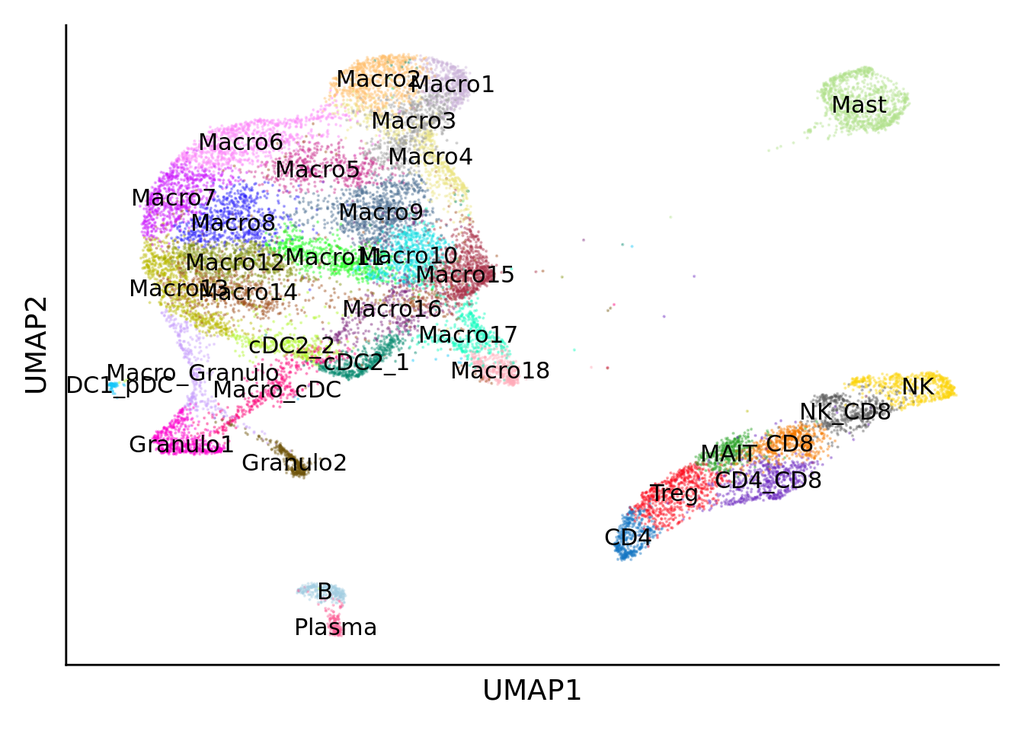

```r
if (!file.exists("ic_figure.qs")) {
    download.file(
        "https://zenodo.org/records/15108216/files/ic_figure.qs?download=1",
        "ic_figure.qs"
    )
}
ic_figure <- qread("ic_figure.qs")
DimPlot(
    ic_figure,
    reduction = "umap.rpca",
    pt.size = .1,
    alpha = .3,
    cols = ic_figure@misc$ic_cluster_col,
    label = TRUE,
    raster = FALSE
) +
    theme(
        axis.text = element_blank(),
        axis.ticks = element_blank()
    ) +
    NoLegend() +
    xlab("UMAP1") +
    ylab("UMAP2")
```

**Feature plots immune cells (Figure 2B)**

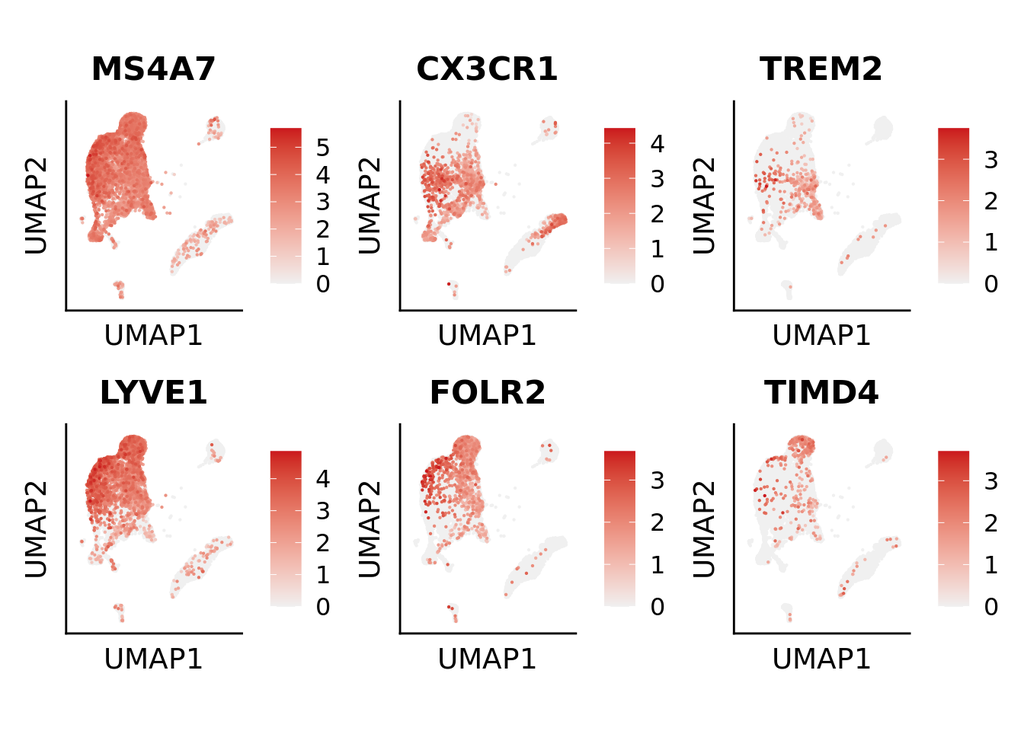

```r
FeaturePlot(
    ic_figure,
    features = c("MS4A7", "CX3CR1", "TREM2", "LYVE1", "FOLR2", "TIMD4"),
    reduction = "umap.rpca",
    pt.size = 0.1,
    raster = FALSE,
    coord.fixed = TRUE,
    cols = c("#F0F0F0", "#CB181D"),
    order = TRUE,
    ncol = 3
) &
    theme(
        axis.text = element_blank(),
        axis.ticks = element_blank()
    ) &
    xlab("UMAP1") &
    ylab("UMAP2")
```

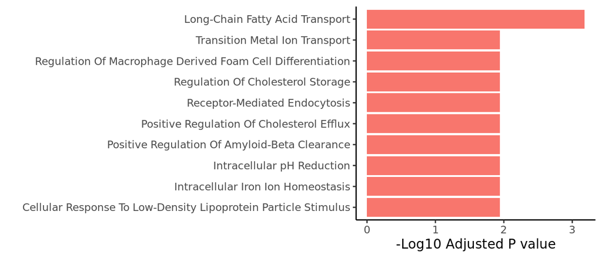

```r
if (!file.exists("enrichr_macro18.qs")) {
    download.file(
        "https://zenodo.org/records/15108216/files/enrichr_macro18.qs?download=1",
        "enrichr_macro18.qs"
    )
}
enrichr_macro18 <- qread("enrichr_macro18.qs")
enrichr_macro18 |>
    dplyr::slice_min(order_by = Adjusted.P.value, n = 10, with_ties = FALSE) |>
    tidyr::separate(Overlap, into = c("overlap1", "overlap2")) |> # separate overlap in two columns
    dplyr::mutate(
        Term = gsub(x = Term, pattern = "\\s\\(.+\\)", replacement = "")
    ) |>
    dplyr::mutate(overlap = as.numeric(overlap1) / as.numeric(overlap2)) |> # calculcate overlap
    ggplot(aes(
        y = reorder(Term, -log10(Adjusted.P.value)),
        x = -log10(Adjusted.P.value)
    )) +
    geom_col(fill = scales::hue_pal()(5)[1]) +
    labs(
        x = "-Log10 Adjusted P value",
        y = ""
    ) +
    theme_classic() +
    theme(legend.position = "none")
```

**Dotplot of SAMC markers in IC (Figure 2D)**

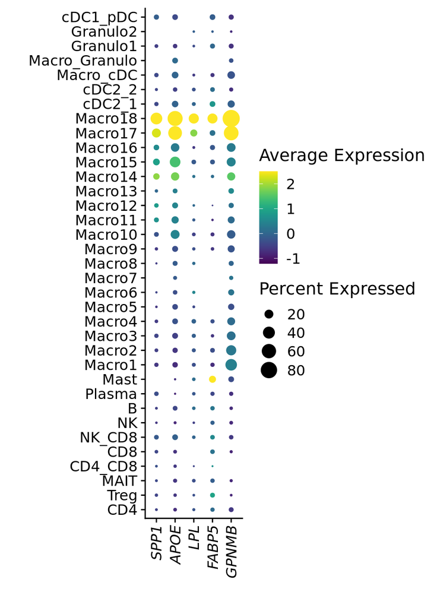

```r
if (!file.exists("dotplot_data_ic_samc.qs")) {
    download.file(
        "https://zenodo.org/records/15108216/files/dotplot_data_ic_samc.qs?download=1",
        "dotplot_data_ic_samc.qs"
    )
}

# Seurat DotPlot function (only ggplot part to avoid calculations)
DotPlotModified <- function(
    data.plot,
    cols = c("lightgrey", "blue"),
    dot.scale = 6,
    scale.by = "radius",
    scale.min = NA,
    scale.max = NA) {
    scale.func <- switch(
        EXPR = scale.by,
        "size" = scale_size,
        "radius" = scale_radius,
        stop("'scale.by' must be either 'size' or 'radius'")
    )
    color.by <- "avg.exp.scaled"
    plot <- ggplot(
        data = data.plot,
        mapping = aes_string(x = "features.plot", y = "id")
    ) +
        geom_point(mapping = aes_string(size = "pct.exp", color = color.by)) +
        scale.func(range = c(0, dot.scale), limits = c(scale.min, scale.max)) +
        theme(axis.title.x = element_blank(), axis.title.y = element_blank()) +
        guides(size = guide_legend(title = "Percent Expressed")) +
        cowplot::theme_cowplot()
    plot <- plot + guides(color = guide_colorbar(title = "Average Expression"))
    return(plot)
}

dotplot_data_ic_samc <- qread("dotplot_data_ic_samc.qs")

DotPlotModified(
    data.plot = dotplot_data_ic_samc,
    scale.by = "size"
) +
    viridis::scale_color_viridis(option = "viridis") +
    theme(
        axis.text.x = element_text(
            angle = 90,
            vjust = 0.5,
            hjust = 1,
            face = "italic"
        ),
    ) +
    xlab("") +
    ylab("")
```

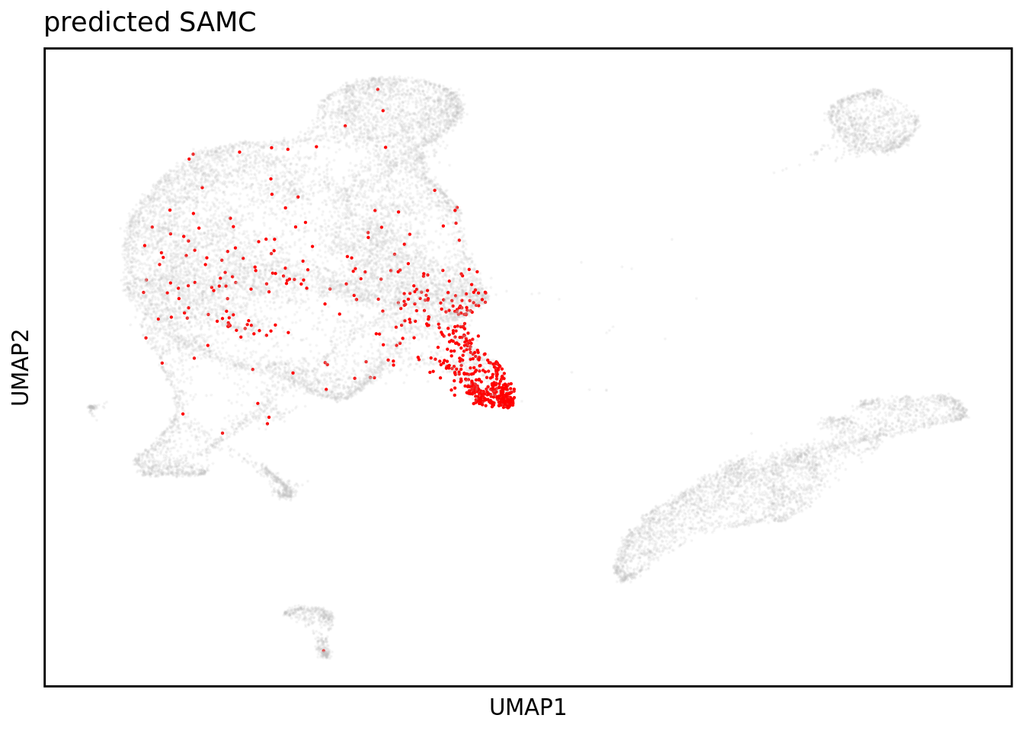

```r
ic_figure <- qread("ic_figure.qs")
plot_predicted_samc <- function(seu_obj) {
    # Create a data frame with alpha values, color values, and UMAP coordinates
    umap_coords <- Embeddings(seu_obj, "umap.rpca")
    alpha_values <- ifelse(seu_obj$stroke_label == "SAMC", 0.5, 0.001)
    color_values <- ifelse(seu_obj$stroke_label == "SAMC", "SAMC", "Other")
    color_map <- setNames(c("red", "grey"), c("SAMC", "Other"))
    plot_df <- data.frame(
        cell = rownames(umap_coords),
        UMAP1 = umap_coords[, 1],
        UMAP2 = umap_coords[, 2],
        alpha = alpha_values,
        color = color_values
    )

    # Create custom ggplot
    samc_predicted <- ggplot(
        plot_df,
        aes(x = UMAP1, y = UMAP2, alpha = alpha, color = color)
    ) +
        geom_point(size = 0.1) +
        scale_color_manual(values = color_map) + # Simplified color scale
        theme_minimal() +
        theme(
            axis.text = element_blank(),
            axis.ticks = element_blank(),
            panel.grid = element_blank(),
            panel.border = element_rect(color = "black", fill = NA, size = 1.0),
            panel.background = element_rect(fill = "white", color = NA),
            plot.background = element_rect(fill = "white", color = NA),
            legend.position = "none"
        ) +
        ggtitle("predicted SAMC")
    return(samc_predicted)
}

plot_predicted_samc(ic_figure)
```

## Figure 3

**Propeller abundance PNP vs CTRL (Figure 3A)**

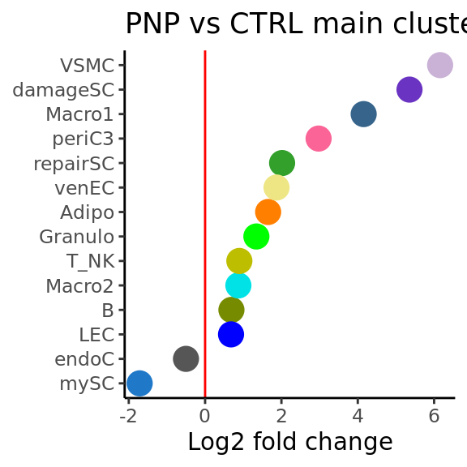

```r
if (!file.exists("propeller_PNP_CTRL.qs")) {
    download.file(
        "https://zenodo.org/records/15108216/files/propeller_PNP_CTRL.qs?download=1",
        "propeller_PNP_CTRL.qs"
    )
}
if (!file.exists("propeller_PNP_CTRL_ic.qs")) {
    download.file(
        "https://zenodo.org/records/15108216/files/propeller_PNP_CTRL_ic.qs?download=1",
        "propeller_PNP_CTRL_ic.qs"
    )
}
propeller_PNP_CTRL <- qread("propeller_PNP_CTRL.qs")
propeller_PNP_CTRL_ic <- qread("propeller_PNP_CTRL_ic.qs")

# function to plot custom dotplot
dotplotPropeller <- function(data, color, title) {
    ggplot(
        data,
        aes(x = log2ratio, y = fct_reorder(cluster, log2ratio), color = cluster)
    ) +
        geom_point(size = 5) +
        theme_classic() +
        geom_vline(
            xintercept = 0,
            color = "red",
            linetype = "solid"
        ) +
        scale_color_manual(values = color) +
        xlab("Log2 fold change") +
        ylab(NULL) +
        theme(legend.position = "none") +
        ggtitle(title)
}
dotplotPropeller(
    propeller_PNP_CTRL,
    color = umap_figure@misc$cluster_col,
    title = "PNP vs CTRL main clusters"
)
```

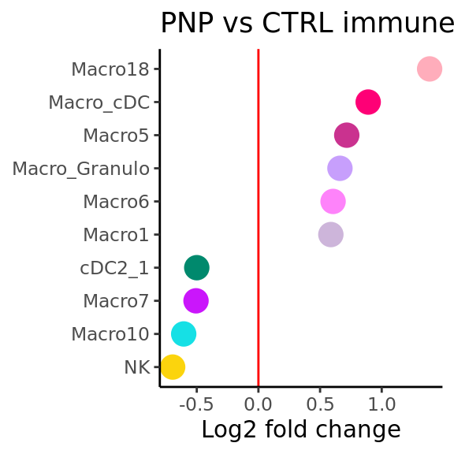

```r
dotplotPropeller(
    propeller_PNP_CTRL_ic,
    color = ic_figure@misc$ic_cluster_col,
    title = "PNP vs CTRL immune cells"
)
```

**Covarying Neighborhood Analysis (Figure 3B)**

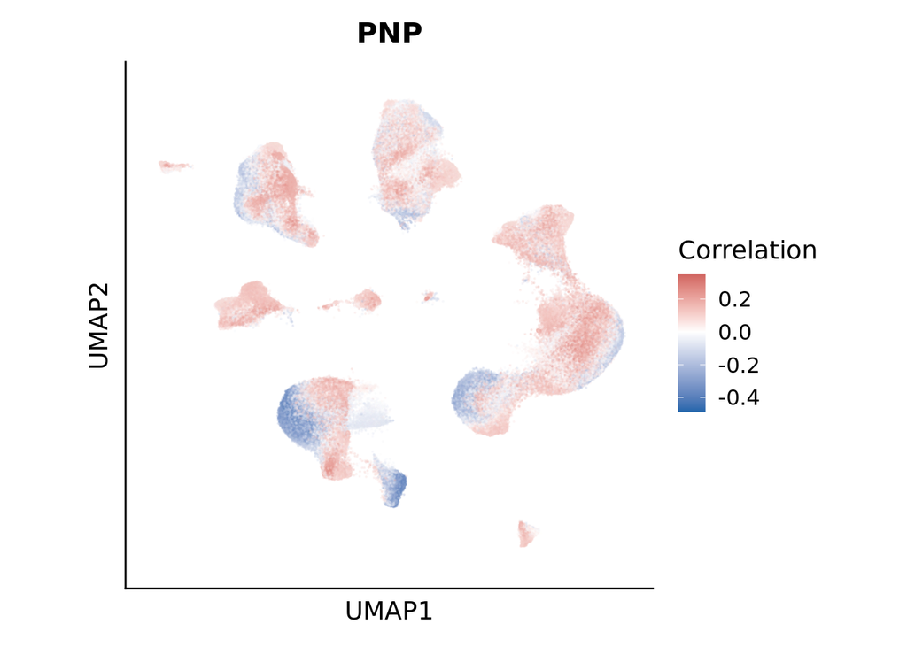

```r
if (!file.exists("cna_pnp_gratio_figure.qs")) {
    download.file(
        "https://zenodo.org/records/15108216/files/cna_pnp_gratio_figure.qs?download=1",
        "cna_pnp_gratio_figure.qs"
    )
}
if (!file.exists("cna_incat_figure.qs")) {
    download.file(
        "https://zenodo.org/records/15108216/files/cna_incat_figure.qs?download=1",
        "cna_incat_figure.qs"
    )
}
cna_pnp_gratio_figure <- qread("cna_pnp_gratio_figure.qs")
cna_incat_figure <- qread("cna_incat_figure.qs")

# function to plot CNA feature plot
fplotCNA <- function(object, feature, title) {
    FeaturePlot(
        object,
        reduction = "umap.scvi.full",
        features = feature,
        pt.size = 0.1,
        order = FALSE,
        coord.fixed = TRUE,
        raster = FALSE,
        alpha = 0.2
    ) +
        scale_colour_gradient2(
            low = "#2166AC",
            mid = "white",
            high = "#B2182B",
            midpoint = 0,
        ) +
        theme(
            axis.text = element_blank(),
            axis.ticks = element_blank(),
        ) +
        labs(
            title = title,
            color = "Correlation",
            x = "UMAP1",
            y = "UMAP2"
        )
}

fplotCNA(cna_pnp_gratio_figure, "cna_ncorrs_pnp", title = "PNP")
```

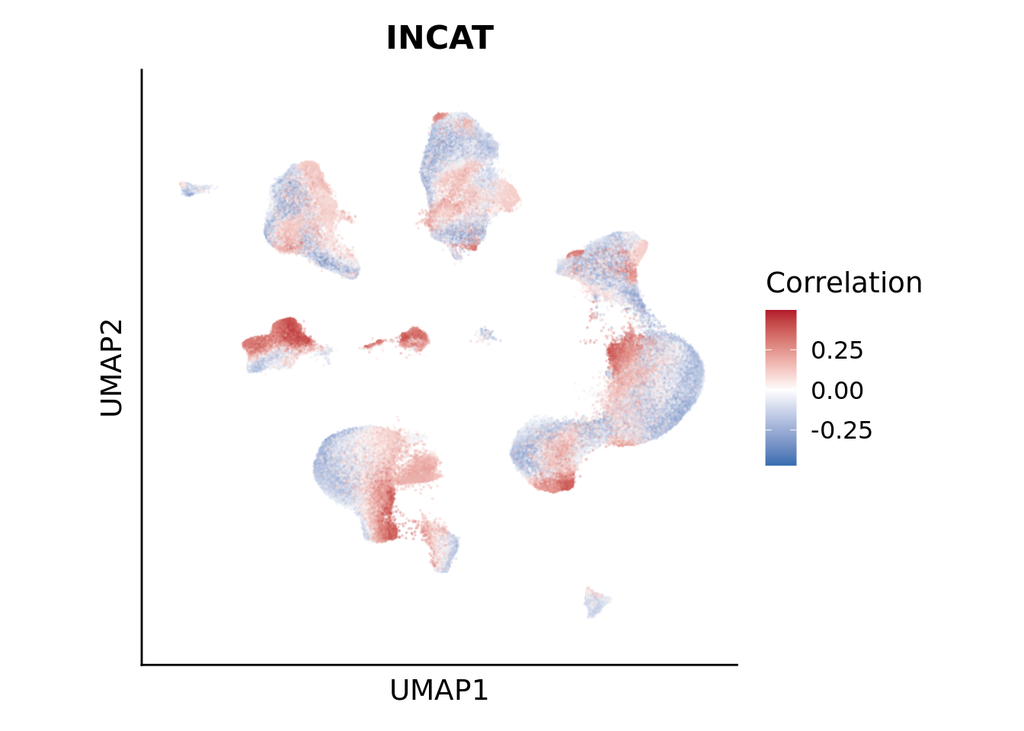

```r
fplotCNA(cna_incat_figure, "cna_ncorrs", title = "INCAT")
```

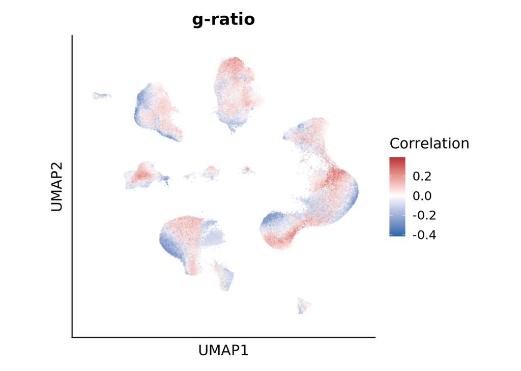

```r
fplotCNA(cna_pnp_gratio_figure, "cna_ncorrs_gratio", title = "g-ratio")
```

**Number of DEGs (Figure 3C)**

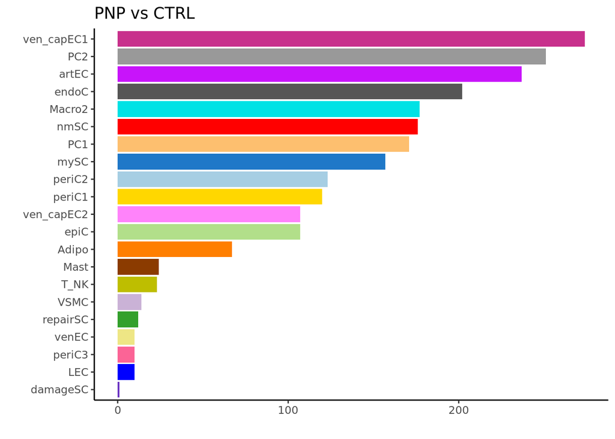

```r
if (!file.exists("pnp_ctrl_pseudobulk_de.qs")) {
    download.file(
        "https://zenodo.org/records/15108216/files/pnp_ctrl_pseudobulk_de.qs?download=1",
        "pnp_ctrl_pseudobulk_de.qs"
    )
}
pnp_ctrl_pseudobulk <- qread("pnp_ctrl_pseudobulk_de.qs")
pnp_ctrl_pseudobulk |>
    mutate(cluster = fct_reorder(cluster, n)) |>
    ggplot(aes(x = cluster, y = n, fill = cluster)) +
    geom_col() +
    coord_flip() +
    scale_fill_manual(values = umap_figure@misc$cluster_col) +
    theme_classic() +
    theme(legend.position = "none") +
    labs(
        x = "",
        y = "",
        title = "PNP vs CTRL"
    )
```

**MiloDE DEGs PNP vs CTRL (Figure 3D)**

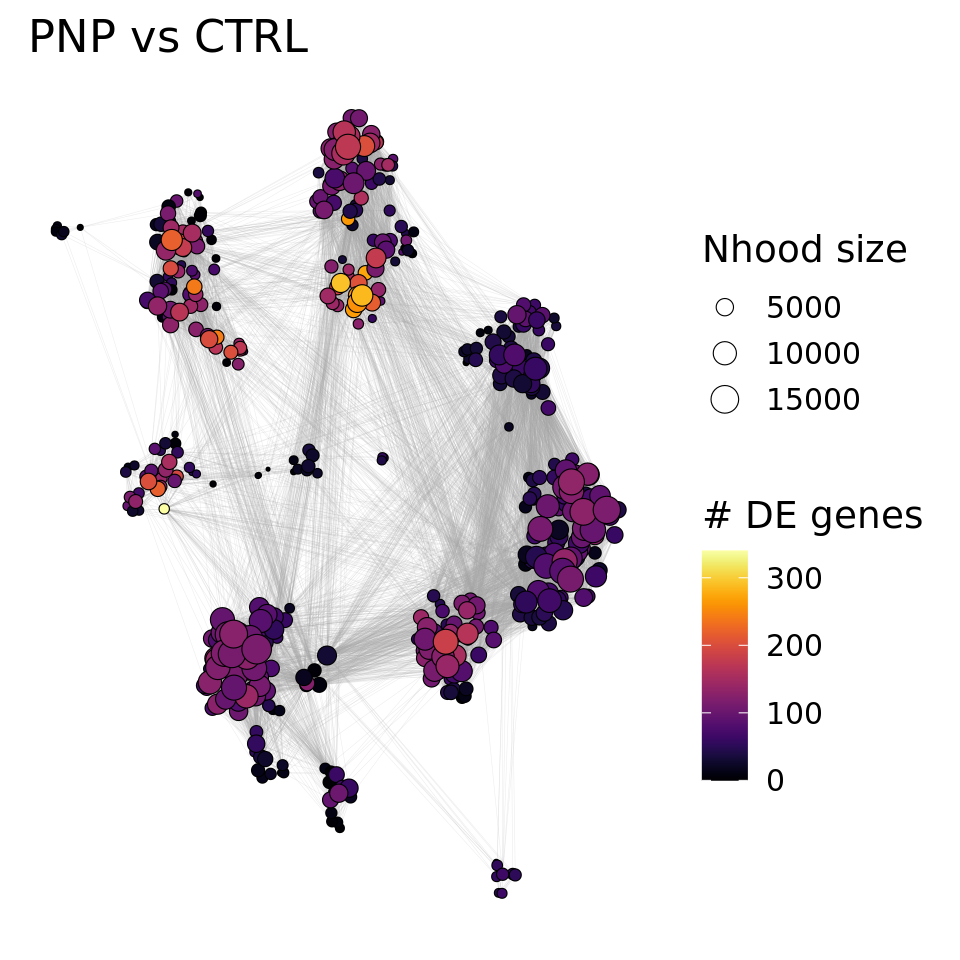

```r
if (!file.exists("milo_figure.qs")) {
    download.file(
        "https://zenodo.org/records/15108216/files/milo_figure.qs?download=1",
        "milo_figure.qs"
    )
}

milo_figure <- qread("milo_figure.qs")
plotMiloDE <- function(condition, title) {
    plot <-
        plot_milo_by_single_metric(
            milo_figure$obj,
            milo_figure$stat[[condition]],
            colour_by = "n_DE_genes",
            layout = "UMAP.SCVI.FULL",
            size_range = c(0.5, 5),
            edge_width = c(0.1, 1.0),
            edge_weight.thres = 10
        ) +
        viridis::scale_fill_viridis(name = "# DE genes", option = "inferno") +
        ggtitle(title)
    print(plot)
}

plotMiloDE("pnp", "PNP vs CTRL")
```

**Pseudobulk DE PNP vs CTRL (Figure 3E)**

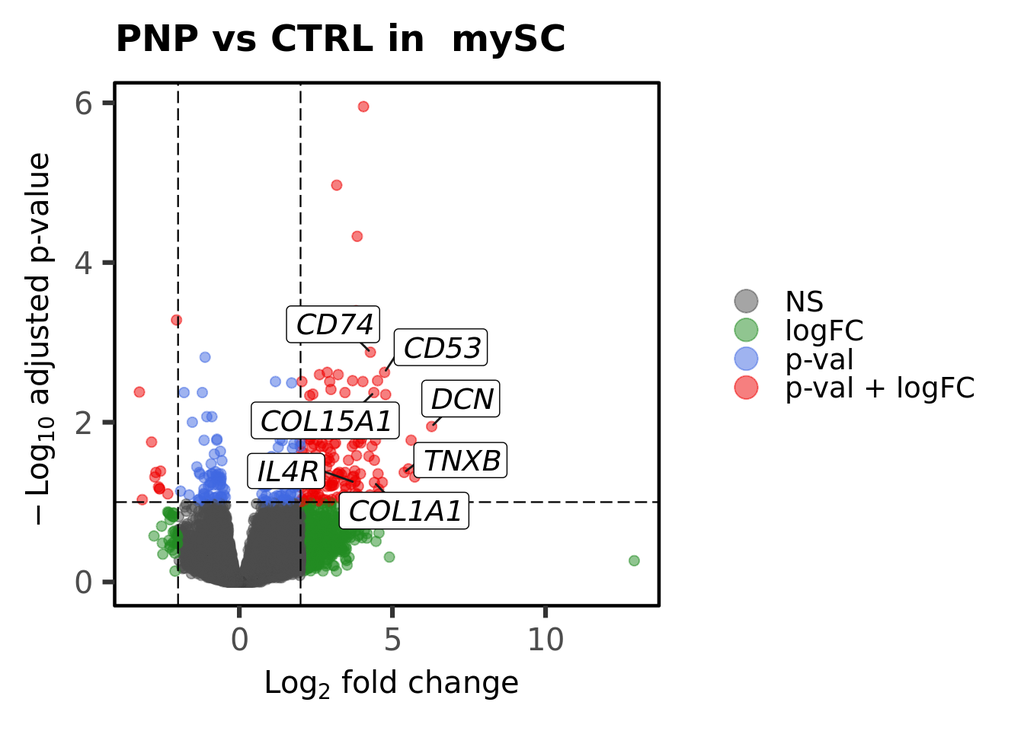

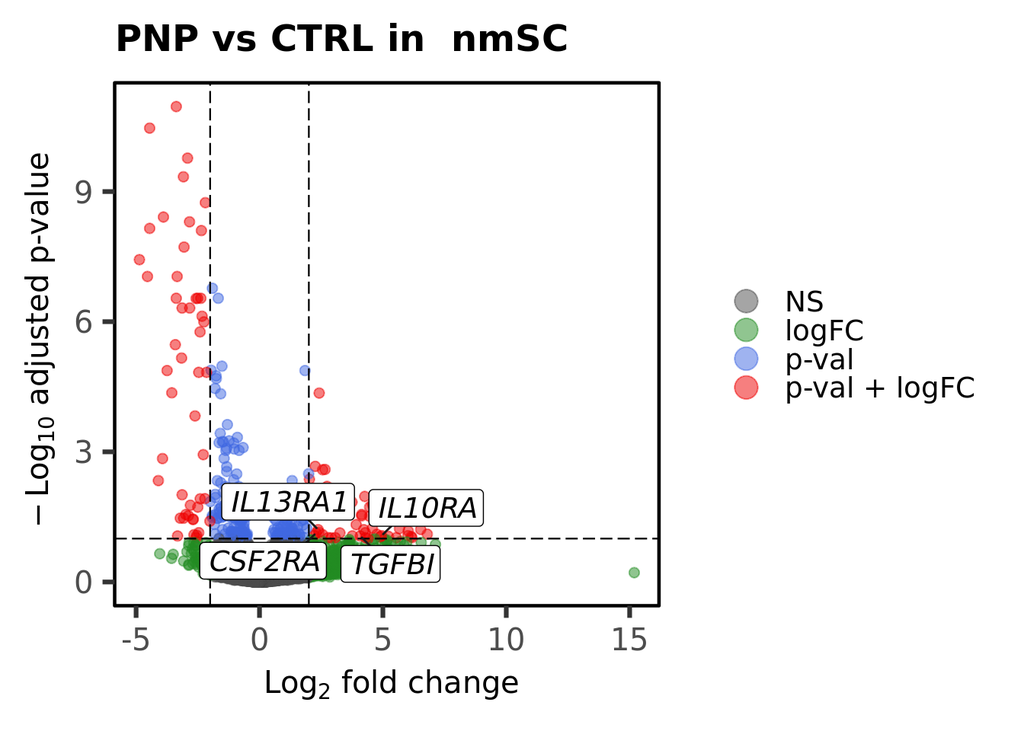

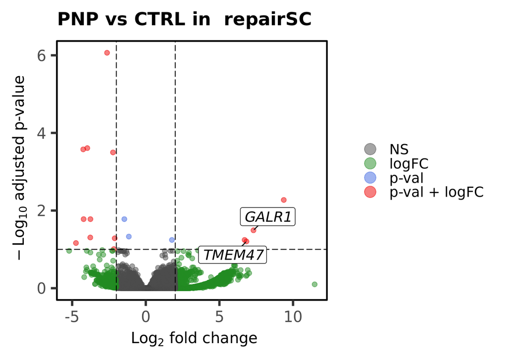

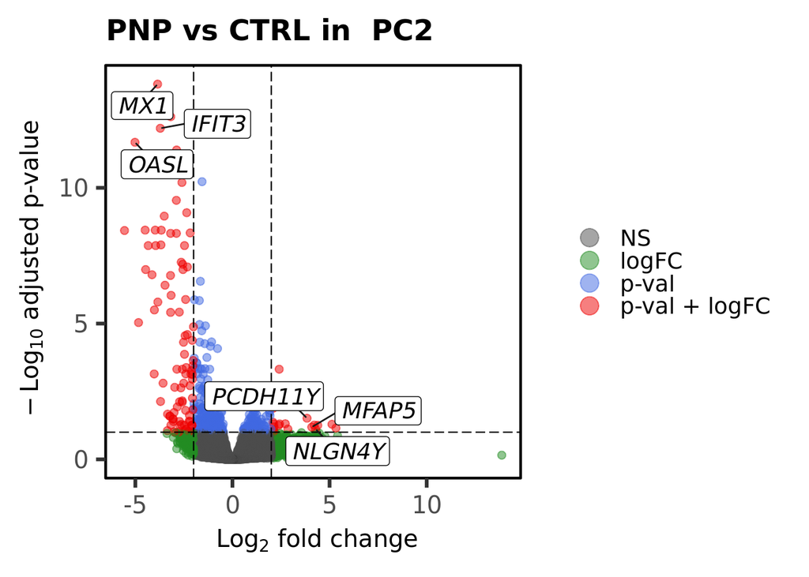

```r
if (!file.exists("de_pseudo_pnp_ctrl.qs")) {
    download.file(
        "https://zenodo.org/records/15108216/files/de_pseudo_pnp_ctrl.qs?download=1",
        "de_pseudo_pnp_ctrl.qs"
    )
}
de_pseudo_pnp_ctrl <- qread("de_pseudo_pnp_ctrl.qs")

# volcano plot function
volcanoPlot <- function(
    cluster,
    input,
    FCcutoff = 2,
    selectLab = NULL,
    drawConnectors = TRUE,
    condition1,
    condition2) {
    input <- input[[cluster]]
    volcano <- EnhancedVolcano::EnhancedVolcano(
        data.frame(input),
        lab = paste0("italic('", input[["gene"]], "')"),
        x = "avg_logFC",
        y = "p_val_adj",
        xlim = c(min(input[["avg_logFC"]], max(input[["avg_logFC"]]))),
        ylim = c(0, max(-log10(input[["p_val_adj"]]))),
        pCutoff = 0.1,
        FCcutoff = FCcutoff,
        axisLabSize = 15,
        pointSize = 2,
        labSize = 5,
        subtitle = NULL,
        caption = NULL,
        border = "full",
        gridlines.major = FALSE,
        gridlines.minor = FALSE,
        drawConnectors = drawConnectors,
        lengthConnectors = unit(0.0001, "npc"),
        title = paste(condition1, "vs", condition2, "in ", cluster),
        boxedLabels = TRUE,
        selectLab = selectLab,
        xlab = bquote(~ Log[2] ~ "fold change"),
        ylab = bquote(~ -Log[10] ~ "adjusted p-value"),
        parseLabels = TRUE,
        legendLabels = c(
            "NS",
            "logFC",
            "p-val",
            "p-val + logFC"
        ),
        legendPosition = "right",
    )
}

# define clusters of interest
cluster_de <- c("mySC", "nmSC", "repairSC", "PC2")

# define genes of interests
lab_pnp_ctrl <- list(
    "mySC" = paste0(
        "italic('",
        c("DCN", "TNXB", "COL1A1", "COL15A1", "CD53", "IL4R", "CD74"),
        "')"
    ),
    "nmSC" = paste0(
        "italic('",
        c("IL10RA", "IL13RA1", "CSF2RA", "TGFBI"),
        "')"
    ),
    "repairSC" = paste0("italic('", c("GALR1", "TMEM47"), "')"),
    "PC2" = paste0(
        "italic('",
        c("MFAP5", "NLGN4Y", "PCDH11Y", "IFIT3", "OASL", "MX1"),
        "')"
    )
)

# plot volcano plots of selected clusters
purrr::walk(
    cluster_de,
    function(cluster) {
        print(volcanoPlot(
            cluster = cluster,
            input = de_pseudo_pnp_ctrl,
            FCcutoff = 2,
            condition1 = "PNP",
            condition2 = "CTRL",
            selectLab = lab_pnp_ctrl[[cluster]]
        ))
    }
)
```

## Figure 4

**Abundance of clusters per PNP subtype (Figure 4A)**

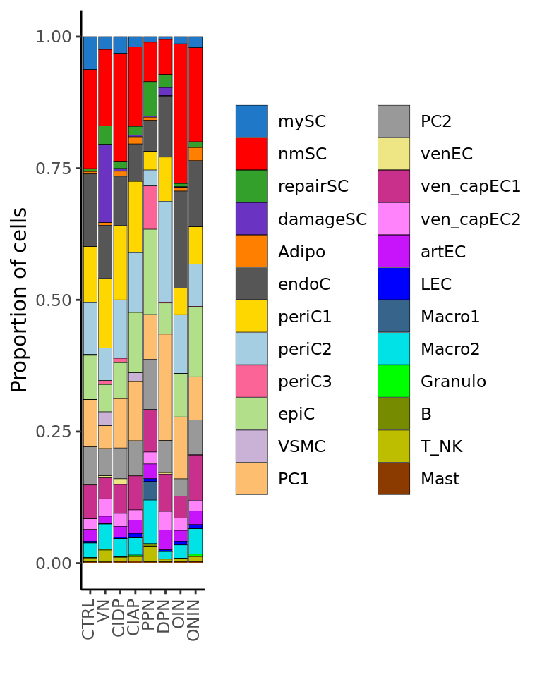

```r
if (!file.exists("abundance_main_clusters.qs")) {
    download.file(
        "https://zenodo.org/records/15108216/files/abundance_main_clusters.qs?download=1",
        "abundance_main_clusters.qs"
    )
}
abundance_main_clusters <- qread("abundance_main_clusters.qs")

abundance_main_clusters |>
    ggplot() +
    geom_col(
        aes(x = type, y = count, fill = cell),
        color = "black",
        linewidth = 0.1,
        position = "fill"
    ) +
    scale_fill_manual(values = umap_figure@misc$cluster_col) +
    guides(fill = guide_legend(title = NULL)) +
    theme_classic() +
    ylab("Proportion of cells") +
    xlab("") +
    theme(
        axis.text.x = element_text(
            angle = 90,
            hjust = 1,
            vjust = 0.3
        )
    )
```

**Propeller abundance of PNP subtypes main cluster (Figure 4B)**

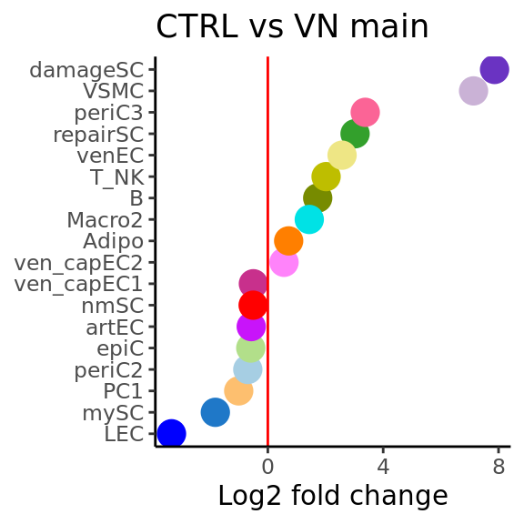

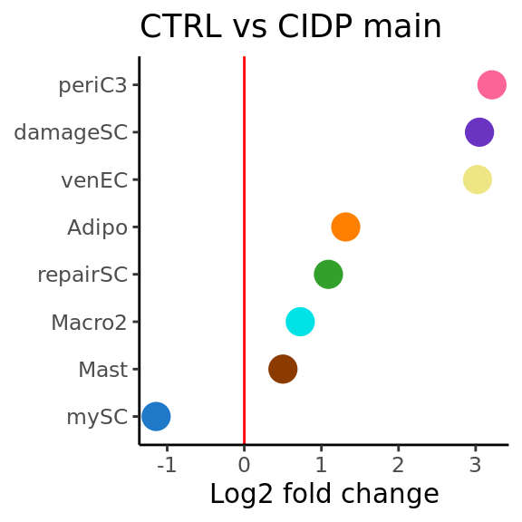

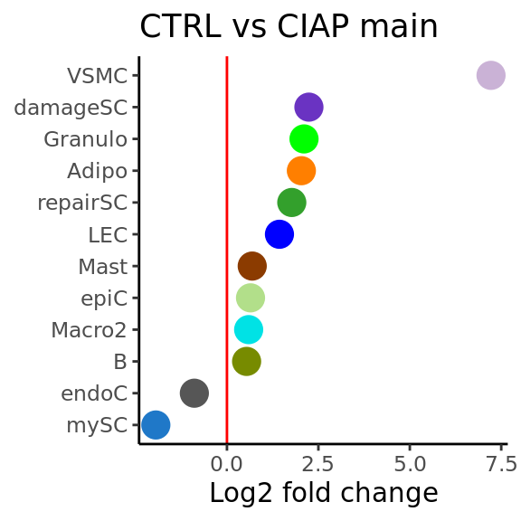

```r
if (!file.exists("propeller_PNP_subtypes_main.qs")) {
    download.file(
        "https://zenodo.org/records/15108216/files/propeller_PNP_subtypes_main.qs?download=1",
        "propeller_PNP_subtypes_main.qs"
    )
}

propeller_PNP_subtypes_main <- qread("propeller_PNP_subtypes_main.qs")
purrr::walk(
    c("VN", "CIDP", "CIAP"),
    function(condition) {
        print(dotplotPropeller(
            propeller_PNP_subtypes_main[[condition]],
            color = umap_figure@misc$cluster_col,
            title = paste0("CTRL vs ", condition, " main")
        ))
    }
)
```

**Propeller abundance of PNP subtypes immune cluster (Figure 4C)**

[figure not shown]

[figure not shown]

[figure not shown]

```r
if (!file.exists("propeller_PNP_subtypes_ic.qs")) {
    download.file(
        "https://zenodo.org/records/15108216/files/propeller_PNP_subtypes_ic.qs?download=1",
        "propeller_PNP_subtypes_ic.qs"
    )
}
propeller_PNP_subtypes_ic <- qread("propeller_PNP_subtypes_ic.qs")
purrr::walk(
    c("VN", "CIDP", "CIAP"),
    function(condition) {
        print(dotplotPropeller(
            propeller_PNP_subtypes_ic[[condition]],
            color = umap_figure@misc$cluster_col,
            title = paste0("CTRL vs ", condition, " immune")
        ))
    }
)
```

**Manual PTPRC quantification in Xenium (Figure 4E)**

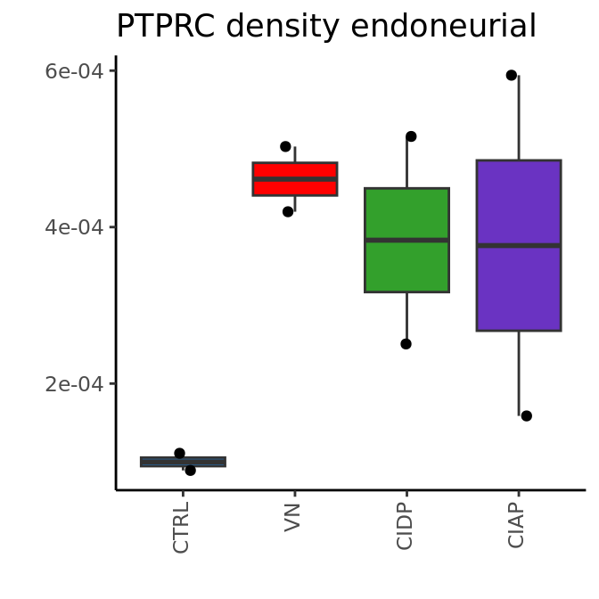

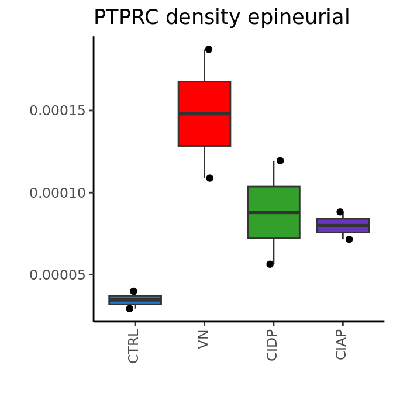

```r
if (!file.exists("manual_xenium_quantification.qs")) {
    download.file(
        "https://zenodo.org/records/15108216/files/manual_xenium_quantification.qs?download=1",
        "manual_xenium_quantification.qs"
    )
}

manual_xenium_quantification <- qread("manual_xenium_quantification.qs")
plotQuanti <- function(y_value, title) {
    plot <-
        manual_xenium_quantification |>
        ggplot(aes(x = level2, y = .data[[y_value]], fill = level2)) +
        geom_boxplot() +
        geom_jitter(height = 0, width = 0.1) +
        scale_fill_manual(values = umap_figure@misc$level2_cols) +
        guides(fill = guide_legend(title = NULL)) +
        theme_classic() +
        xlab("") +
        ylab("") +
        ggtitle(title) +
        theme(
            legend.position = "none",
            axis.text.x = element_text(
                angle = 90,
                hjust = 1,
                vjust = 0.3,
            )
        )
    print(plot)
}

purrr::walk2(
    c("endoPTPRC_density_sum", "epiPTPRC_density"),
    c("PTPRC density endoneurial", "PTPRC density epineurial"),
    function(y_value, title) {
        plotQuanti(y_value = y_value, title = title)
    }
)
```

**MiloDE DEGs PNP subtypes(Figure 4G)**

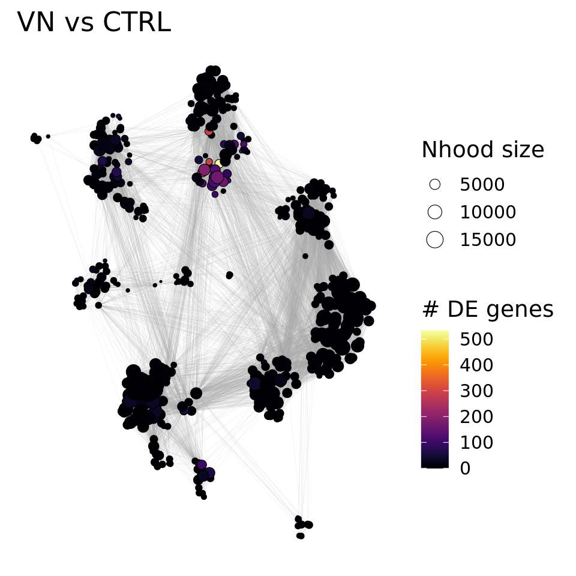

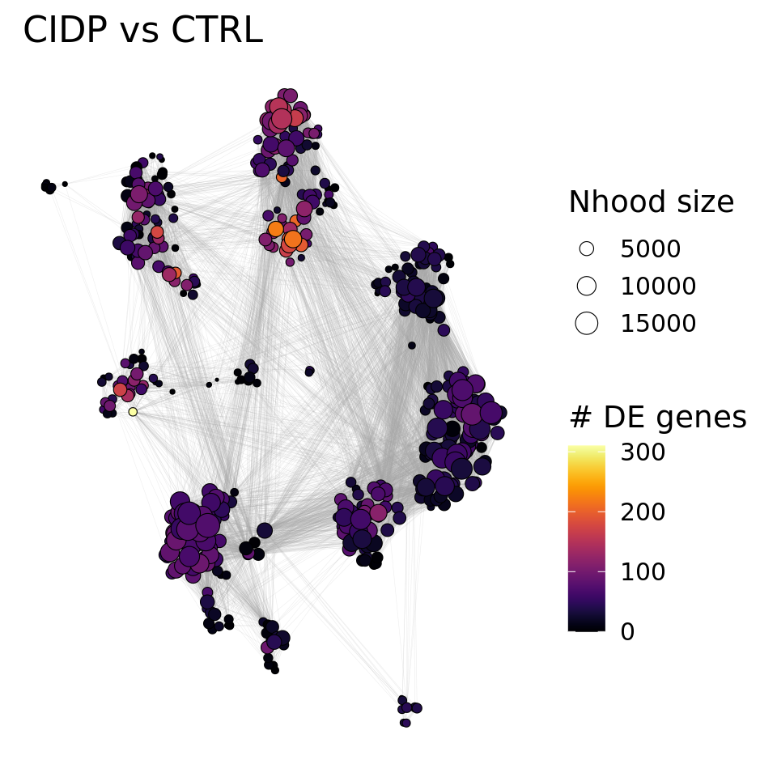

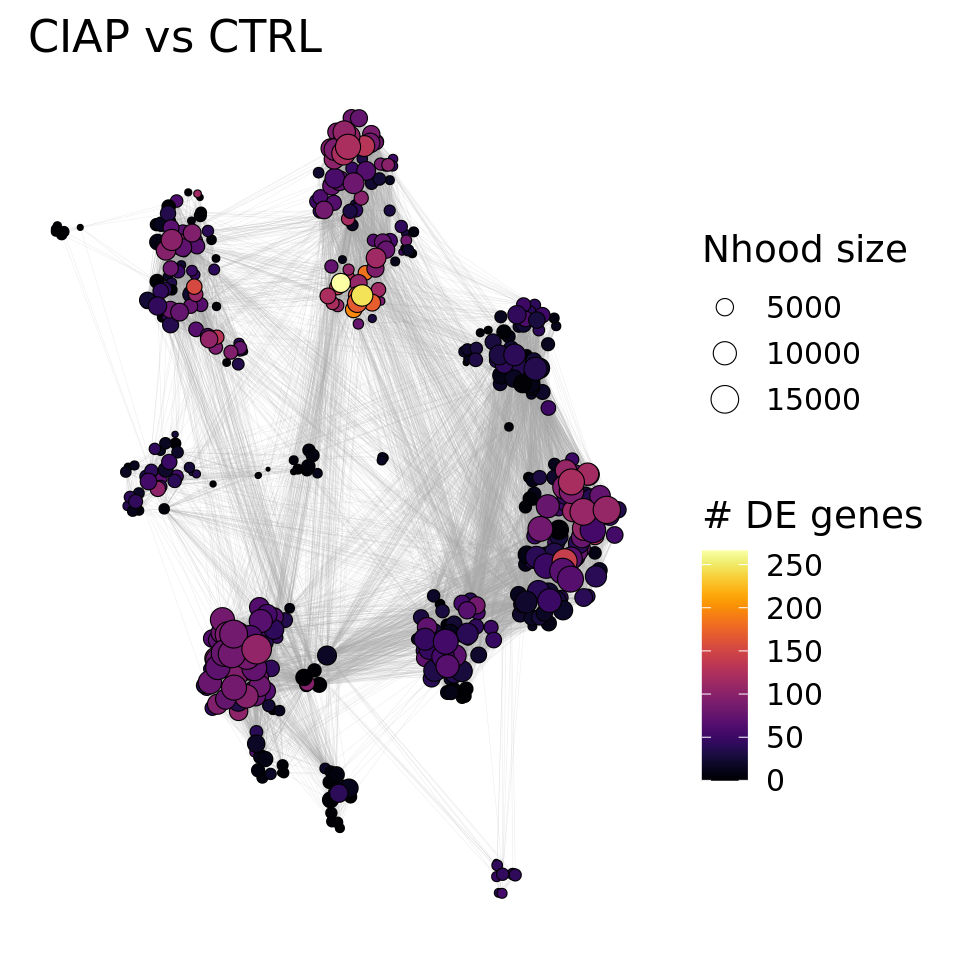

```r
purrr::walk2(
    c("vn", "cidp", "ciap"),
    c("VN vs CTRL", "CIDP vs CTRL", "CIAP vs CTRL"),
    function(condition, title) {
        plotMiloDE(condition, title)
    }
)
```